# Aula 8

Mahayana Godoy

# ANOVA

# ANOVA

A ANOVA pode ser descrita como um teste-t que dá conta de mais níveis e dá respostas sobre *efeitos principais* e *interação*. Hoje vamos ver:

- O que é ANOVA
- Como realizar o teste no R
- Como fazer múltiplas comparações
- Como analisar os resultados

# Problemas do dia

# Problemas do dia

O arquivo Covariaveis.csv traz a taxa de realização concordância nominal não padrão de falantes de português. Também traz o gênero desses falantes e sua escolaridade.

Você tem alguma hipótese sobre como a taxa de realização dessa variante pode ser influenciada por gênero e escolaridade?

Como testar sua hipótese?

# Problemas do dia

Há algumas aulas, vimos o trabalho de Baumann e Jones, que coletaram dados para investigar os métodos de ensino STRAT e DRTA.

Como saber se esses as notas das provas dos alunos que tiveram aula com cada método são diferentes entre si?

# Múltiplas comparações

O problema das múltiplas comparações (ou seja, fazer vários teste-t) é aumentar nossa taxa de falso positivo/falso negativo.

Podemos olhar se há um *efeito principal* da variável que queremos testar.

- Gênero e escolaridade influenciam taxa de produção de uma variante?
- Métodos de ensino influenciam o desempenho de estudantes em provas?

Se a resposta for “não”, nem adianta fazermos comparações entre os grupos.

# ANOVA: análises de variância

# Questões importantes

Quando usar?

- Quando eu quero testar o efeito de uma ou mais variáveis independentes categóricas em uma variável dependente numérica, e preciso fazer inferências sobre interações e/ou comparações de análises entre três ou mais níveis.

O que são variáveis categóricas mesmo?

- Uma variável que contem níveis finitos, como cor dos olhos, nacionalidade, gênero, tipo de cerveja etc.

Existe apenas um tipo de ANOVA?

- Não. Se você quer testar apenas o efeito de uma variável, você faz uma One-way ANOVA, se forem duas variáveis, uma Two-way ANOVA, se você quiser testar a interação entre duas variáveis, você tem uma Two-way ANOVA com interação etc.

# Tabela

Essa tabela resume alguns dos tipos de ANOVA que existem e que perguntas elas respondem

| Pergunta | Análise | Fórmula |
| --- | --- | --- |
| O gênero influencia a produção de uma variante? | One-way ANOVA | RT ~ SEXO.GENERO |
| Escolaridade influencia a produção de uma variante? | One-way ANOVA | RT ~ ESCOLARIDADE |
| Há efeito principal de gênero ou escolaridade na produção de uma variante? | Two-way ANOVA | RT ~ SEXO.GENERO + ESCOLARIDADE |
| O efeito de gênero depende da escolaridade? | Two-way ANOVA com interação | RT ~ SEXO.GENERO * ESCOLARIDADE |

Há ainda outros tipos de ANOVA, que respondem perguntas diferentes. Discutiremos esses casos ao longo das próximas aulas.

# Exemplo

Vamos ilustrar o uso da ANOVA com o conjunto de dados `poopdeck`, do pacote YaRrr (Phillips, 2017).

[figure not shown]

*YaRrr! The Pirate’s Guide to R* é um excelente tutorial para aprender a fazer análises no R. Salve na sua aba de favoritos para consultar quando precisar

https://bookdown.org/ndphillips/YaRrr/

# Exemplo

Você pode instalar e carregar o pacote com os comandos abaixo.

```r
install.packages("yarrr")
library(yarrr)
```

Para facilitar, eu criei um arquivo csv para trabalharmos com o arquivo `poopdeck`. Importe-o para sua área de trabalho usando a função read.csv

```r
poopdeck = read.csv("poopdeck.csv")
```

# Exemplo

O conjunto poopdeck traz a informação sobre quanto tempo levou para limpar os dejetos de papagaios e tubarões de uma parte da popa chamada *poopdeck*. Para a limpeza dos dejetos, foram usados três produtos de limpeza, *a*, *b* e *c*.

Dê uma olhada no conjunto de dados. Se tiver dúvidas sobre as variáveis, consulte o help do R com `?poopdeck`

```r
head(poopdeck)
```

| day | cleaner | type | time |
| --- | --- | --- | --- |
| 1 | a | parrot | 47 |
| 1 | b | parrot | 55 |
| 1 | c | parrot | 64 |
| 1 | a | shark | 101 |
| 1 | b | shark | 76 |
| 1 | c | shark | 63 |

# Exemplo

Considerando os boxplot dos dados de tempo de limpeza, você acha que um dos limpadores é mais eficiente? E algum dos dejetos é mais difícil de limpar?

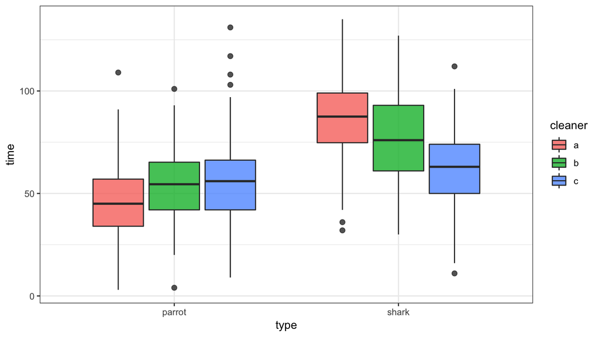

# Exemplo

Essa tabela resume as perguntas que podemos fazer a partir desses dados.

| Pergunta | Análise | Fórmula |
| --- | --- | --- |
| Existe diferença entre os diferentes produtos com relação ao tempo de limpeza, independente do tipo de dejeto? | One-way ANOVA | time ~ cleaner |
| Existe diferença entre os diferentes dejetos com relação ao tempo de limpeza, independente do tipo de produto usado? | One-way ANOVA | time ~ type |
| Há efeito principal de tipo de dejeto ou produto no tempo de limpeza? | Two-way ANOVA | time ~ cleaner + type |
| O efeito do produto de limpeza depende do tipo de dejeto? | Two-way ANOVA com interação | time ~ cleaner * type |

Antes de seguir, vamos entender um pouco o que um teste ANOVA faz.

# O que é ANOVA?

ANOVA: Análise de Variância

O que significa *variância*?

- A variância dos dados reflete quanto os dados variam (duh!)

Por que usar variância em um teste para comparar médias?

- Vendo o quanto há de variação entre os grupos (“type” e “cleaner”) e *dentro* dos grupos, podemos ter uma ideia se a diferença entre as médias é realmente significativa.

# O que é ANOVA?

A diferença entre as médias é a mesma em (1) e (2). Porém, apenas no gráfico (2) podemos perceber que as médias são realmente diferentes entre si. Por quê?

**1)**

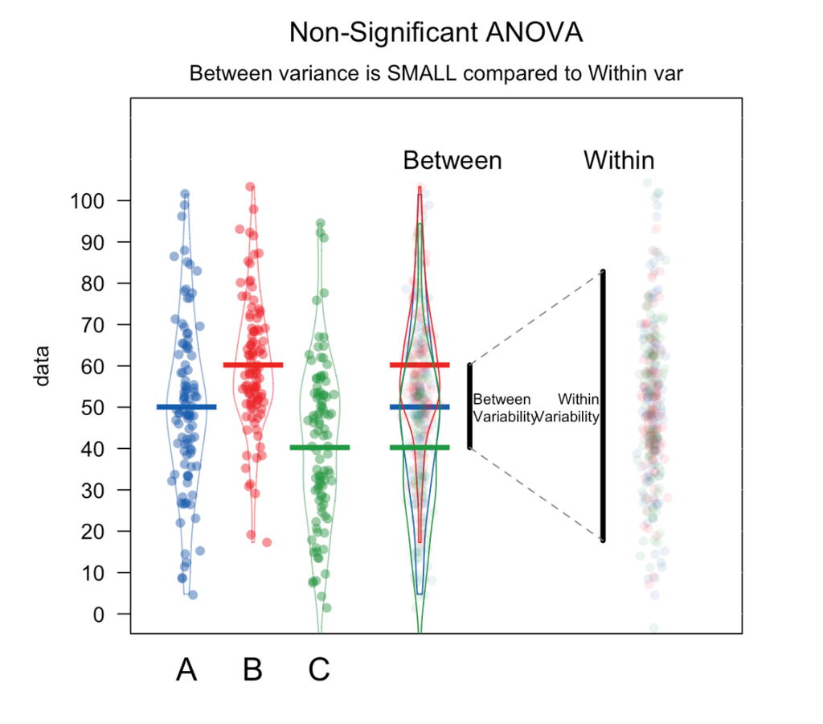

**2)**

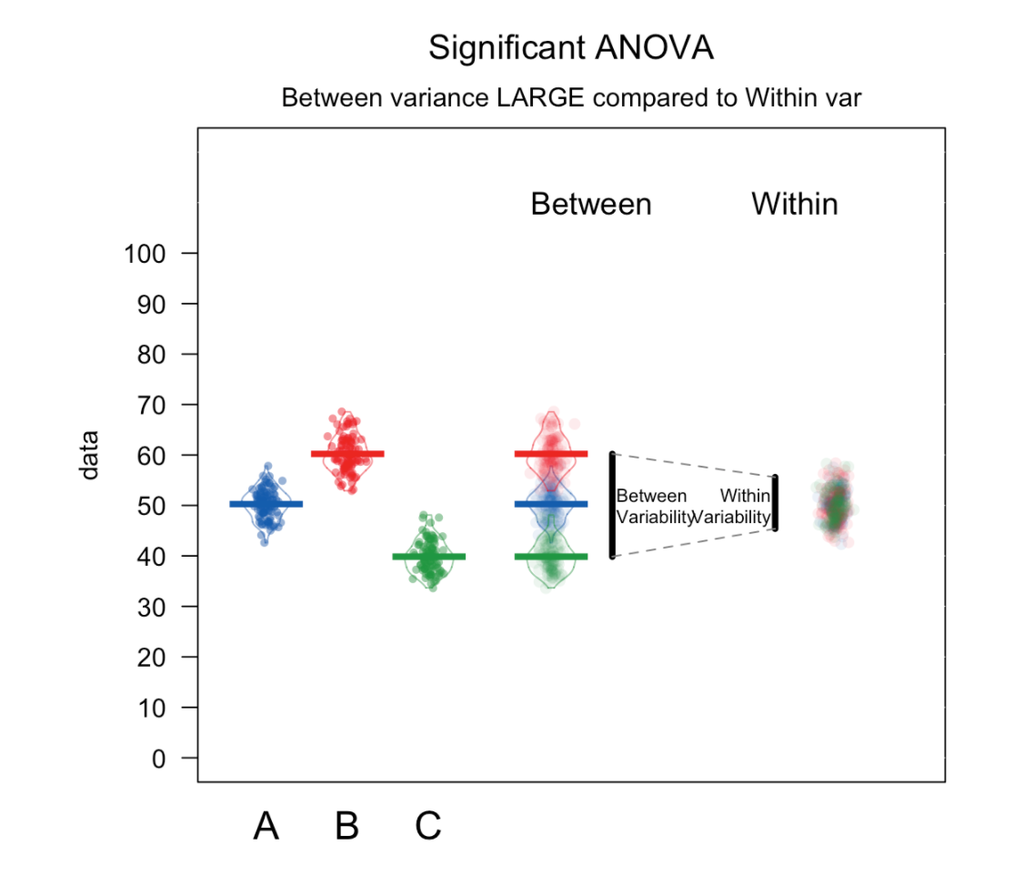

**Fonte:** https://bookdown.org/ndphillips/YaRrr/full-factorial-between-subjects-anova.html

# O que é ANOVA?

**Teste-t:** calcula probabilidades a partir de uma distribuição t

- $$t = \frac{\bar{X}-\mu}{\frac{s}{\sqrt{n}}}$$

**ANOVA:** calcula probabilidades a partir de uma distribuição F

- $$F = \frac{\text{variância entre os grupos}}{\text{variância dentro dos grupos}}$$
- **Pergunta:** sabendo que variância nunca é um número negativo (pois deriva de um valor elevado ao quadrado), qual o menor valor que *F* pode assumir?

# O que é ANOVA?

Essa aqui é uma distribuição *F*.

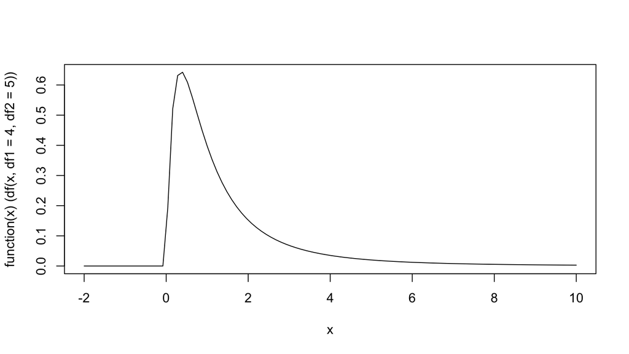

Se a variância *entre grupos* e *dentro dos grupos* for igual, qual o valor de F?

# O que é ANOVA?

O valor será igual a 1 (indicado pelo ponto vermelho).

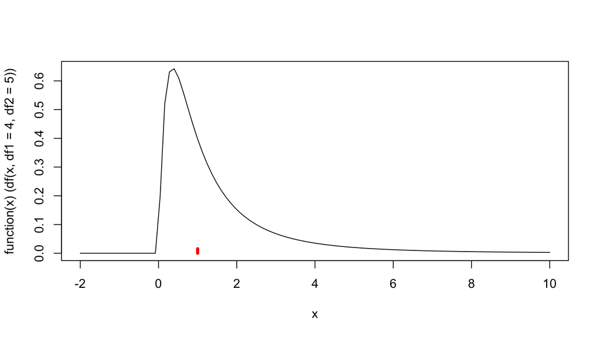

Se a variância entre grupos for 4 vezes maior que a variância dentro dos grupos, qual será o valor de F?

# O que é ANOVA?

Qual valor é mais extremo?

# O que é ANOVA

Qual valor indica que há maior chance de haver um efeito do tipo de grupo (a condição testada) no resultado medido?

Em qual desses casos há mais chance de haver um efeito da condição testada, ou seja, a fonte que causaria uma variação entre grupos?

# O que é ANOVA?

Continuamos calculando probabilidades para decidir se rejeitamos $H_0$!

# Pequena pausa para pensar

**Qual é a $H_0$ da ANOVA?**

- Não há diferença entre as médias dos níveis testados.

**Qual é a $H_a$ da ANOVA?**

- Há *ao menos* uma diferença entre as médias dos níveis testados.

# O que é uma ANOVA?

Abaixo temos duas distribuições *F*, ligeiramente diferentes porque seus *graus de liberdade* (ou *degrees of freedom*) são diferentes.

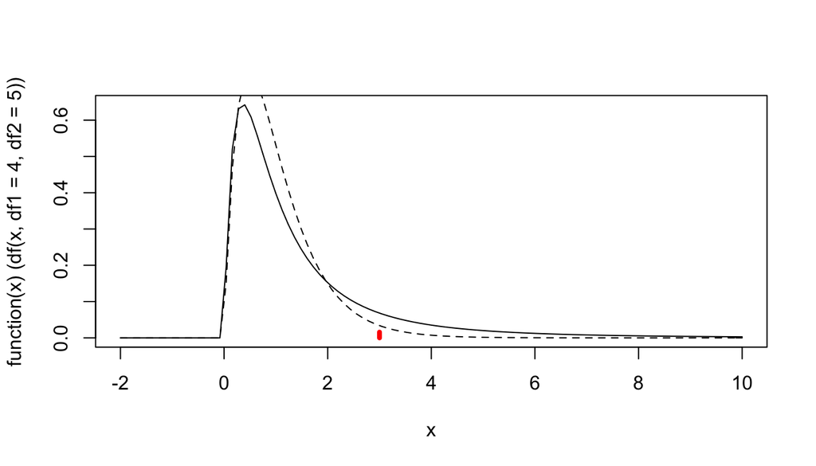

**Fonte:** Winter (2015)

Em qual das duas a probabilidade de haver um valor igual ou maior que 3 (ponto vermelho) é menor?

# O que é uma ANOVA?

Na distribuição *F* de linha pontilhada, pois a área será menor.

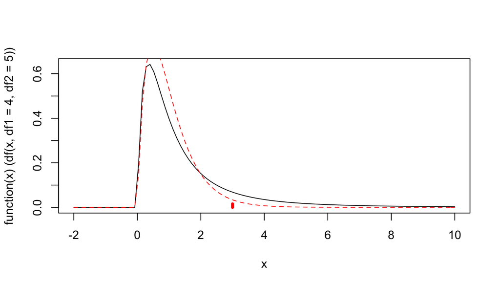

**Conclusão:** Graus de liberdade (*dfs*) influenciam no *p* associado a um valor *F* (já havíamos visto isso para a distribuição *t*)

# O que é uma ANOVA?

A distribuição *F* é desenhada a partir de *dois* números de *degrees of freedom*: o primeiro leva em consideração o **número de grupos comparados**, o segundo leva em consideração o **número de observações** que temos.

Não vamos entrar nos detalhes do cálculo de *dfs* para uma ANOVA porque há diferentes ANOVAs que podemos fazer e elas diferiram no modo como os *dfs* específicos são calculados.

Apenas lembre que é importante reportar esses *dfs* porque, assim como para a distribuição *t*, eles determinam a distribuição *F*.

# ANOVA: trivia

Por que a distribuição chama “Distribuição *F*”?

Porque foi nomeada em homenagem a sir Ronald **F**isher, o Saussure da estatística.

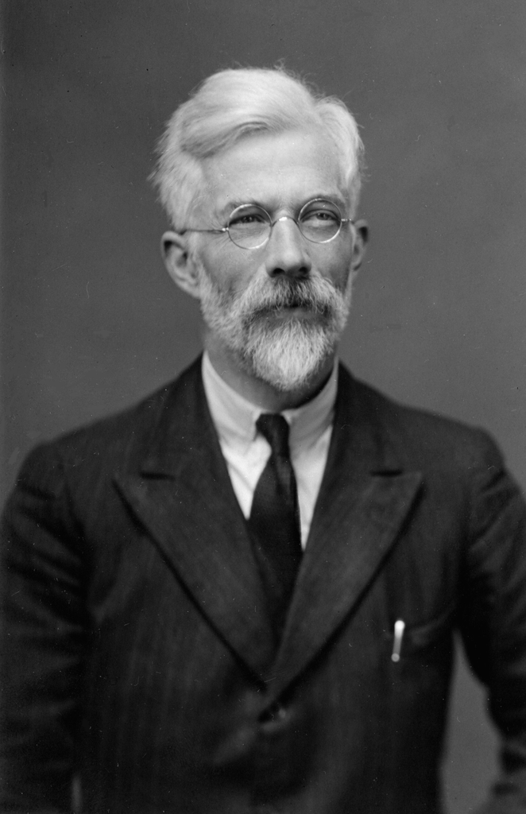

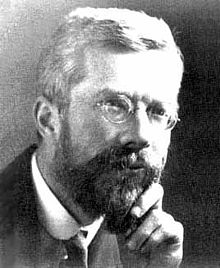

# Tabela ANOVA

O resultado de um teste ANOVA retorna os valores necessários para calcular um valor *F* e a probabilidade associada àquele valor naquelas condições. Isso tudo é escrito em uma tabela.

| Fonte da variação | Graus de Liberdade | Soma dos Quadrados | Quadrado Médio | Razão de Variâncias | Probabilidade |
| --- | --- | --- | --- | --- | --- |
| Entre grupos | $df_{entre.grupos}$ | $SS_{entre.grupos}$ | $MS_{entre.grupos}$ | *F* | *p* |
| Dentro dos grupos | $df_{dentro.grupos}$ | $SS_{dentro.grupos}$ | $MS_{dentro.grupos}$ |  |  |

A partir de dos graus de liberdade e da soma dos quadrados, derivam-se os valores dos quadrados médios. A razão entre os valores dos quadrados médios é igual a *F*.

# One-way ANOVA

# Exemplo

One-way ANOVA: Existe diferença entre os diferentes produtos com relação ao tempo de limpeza, independente do tipo de dejeto? (time ~ cleaner)

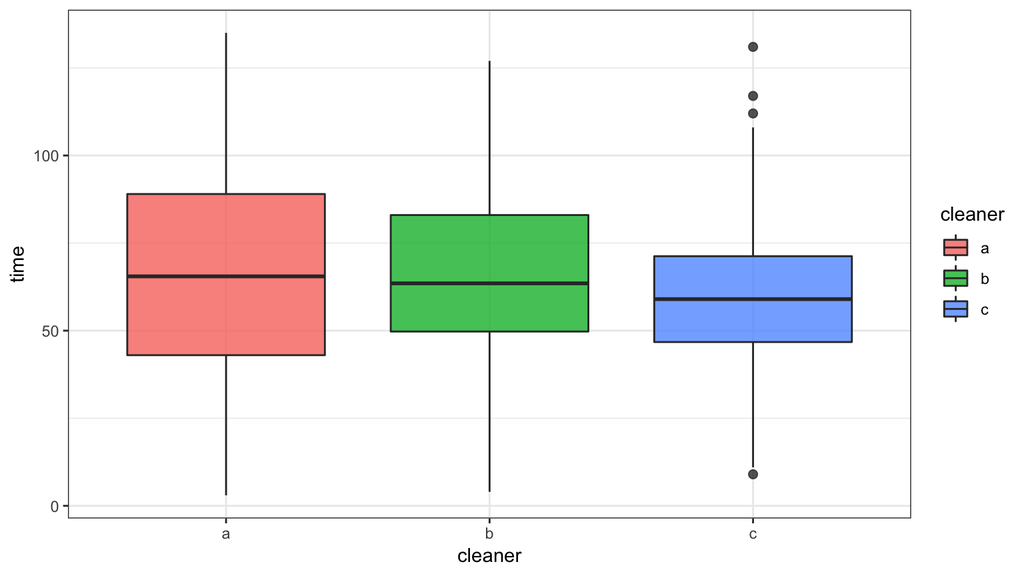

# Exemplo

One-way ANOVA: Existe diferença entre os diferentes produtos com relação ao tempo de limpeza, independente do tipo de dejeto? (time ~ cleaner)

Primeiro nós fazemos um modelo, com a função `aov` para responder a pergunta que nos interessa.

```r
modelo.cleaner <- aov(time ~ cleaner, data = poopdeck)
```

Agora tiramos a nossa tabela desse modelo através da função `summary`

```r
summary(modelo.cleaner)
```

# Exemplo

```r
modelo.cleaner <- aov(time ~ cleaner, data = poopdeck)

summary(modelo.cleaner)
```

Analysis of Variance Model

|  | Df | Sum Sq | Mean Sq | F value | Pr(>F) |
| --- | --- | --- | --- | --- | --- |
| **cleaner** | 2 | 6057 | 3028 | 5.29 | 0.00526 |
| **Residuals** | 597 | 341511 | 572 |  |  |

Perceba que o nome *cleaner* está na linha que mostra a variação *entre grupos*. A linha que mostra a variação *dentro dos grupos* recebe o nome de *Residuals*.

Perceba também que a média de variação entre grupos foi maior do que a variação dentro dos grupos (cf. *Mean sq*).

# Exemplo

```r
modelo.cleaner <- aov(time ~ cleaner, data = poopdeck)

summary(modelo.cleaner)
```

Analysis of Variance Model

|  | Df | Sum Sq | Mean Sq | F value | Pr(>F) |
| --- | --- | --- | --- | --- | --- |
| **cleaner** | 2 | 6057 | 3028 | 5.29 | 0.00526 |
| **Residuals** | 597 | 341511 | 572 |  |  |

Há *efeito principal* de produto de limpeza?

- Há um efeito do produto de limpeza no tempo gasto para limpar o convés (F(2,597)=5.29, p = 0.005).
- Mas que diferença é essa?! Os três são diferentes entre si? Há apenas diferença entre A e B?

# Exemplo

Fazemos agora um teste post-hoc, com múltiplas comparações, para ver qual foi a diferença.

A maneira mais comum é fazer um Teste de Tukey, que já retorna múltiplas comparações com o p-valor ajustado pelo método de Tukey.

```r
TukeyHSD(modelo.cleaner)
```

- **cleaner**:

  |  | diff | lwr | upr | p adj |
  | --- | --- | --- | --- | --- |
  | **b-a** | -0.42 | -6.04 | 5.2 | 0.9831 |
  | **c-a** | -6.94 | -12.56 | -1.32 | 0.01073 |
  | **c-b** | -6.52 | -12.14 | -0.9004 | 0.01809 |

# Exemplo

- **cleaner**:

  |  | diff | lwr | upr | p adj |
  | --- | --- | --- | --- | --- |
  | **b-a** | -0.42 | -6.04 | 5.2 | 0.9831 |
  | **c-a** | -6.94 | -12.56 | -1.32 | 0.01073 |
  | **c-b** | -6.52 | -12.14 | -0.9004 | 0.01809 |

**diff:** diferença das médias entre as condições

**lwr/upr:** intervalo de confiança para a diferença entre as médias (lembre-se: um teste-t testa se a diferença entre as médias é 0)

**p adj:** p-valor do teste da $H_0$, segundo a qual a diferença entre as médias é 0

# Exemplo

- **cleaner**:

  |  | diff | lwr | upr | p adj |
  | --- | --- | --- | --- | --- |
  | **b-a** | -0.42 | -6.04 | 5.2 | 0.9831 |
  | **c-a** | -6.94 | -12.56 | -1.32 | 0.01073 |
  | **c-b** | -6.52 | -12.14 | -0.9004 | 0.01809 |

Uma one-way ANOVA monstrou um efeito significativo do produto de limpeza no tempo gasto para limpar o convés (F(2,597)=5.29, p = 0.005). Análises post-hoc a partir de um teste de Tukey identificaram que o uso do produto *c* leva a menores tempos de limpeza que o uso do produto *a* (p < 0.02) e *b* (p <0.02), mas não houve diferença do tempo gasto quando comparados os produtos *a* e *b* (p = 0.9)

# Two-way ANOVA

# Exemplo

E se, além do efeito do tipo de produto, eu quisesse saber também se existe diferença entre os diferentes tipos de dejetos com relação ao tempo de limpeza? Como eu escrevo a fórmula?

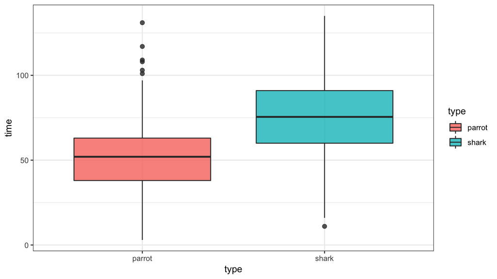

- Fórmula: `time ~ cleaner + type`

# Exemplo

Two-way ANOVA: Há efeito principal de tipo de dejeto ou produto no tempo de limpeza?? (time ~ cleaner + type)

Primeiro nós fazemos um modelo, com a função `aov` para responder a pergunta que nos interessa.

```r
modelo.cleaner.type <- aov(time ~ cleaner + type, data = poopdeck)
```

Agora tiramos a nossa tabela desse modelo através da função `summary`

```r
summary(modelo.cleaner.type)
```

# Exemplo

```r
modelo.cleaner.type <- aov(time ~ cleaner + type, data = poopdeck)

summary(modelo.cleaner.type)
```

Analysis of Variance Model

|  | Df | Sum Sq | Mean Sq | F value | Pr(>F) |
| --- | --- | --- | --- | --- | --- |
| **cleaner** | 2 | 6057 | 3028 | 6.94 | 0.00104 |
| **type** | 1 | 81620 | 81620 | 187 | 2.99e-37 |
| **Residuals** | 596 | 259891 | 436 |  |  |

Perceba que agora há duas linhas que mostram a variação *entre grupos*: *cleaner* e *type*. A linha que mostra a variação *dentro dos grupos* recebe o nome de *Residuals*.

Perceba também que a variação entre grupos foi maior do que a variação dentro dos grupos (cf. *Mean sq*).

# Exemplo

```r
modelo.cleaner.type <- aov(time ~ cleaner + type, data = poopdeck)

summary(modelo.cleaner.type)
```

Analysis of Variance Model

|  | Df | Sum Sq | Mean Sq | F value | Pr(>F) |
| --- | --- | --- | --- | --- | --- |
| **cleaner** | 2 | 6057 | 3028 | 6.94 | 0.00104 |
| **type** | 1 | 81620 | 81620 | 187 | 2.99e-37 |
| **Residuals** | 596 | 259891 | 436 |  |  |

Há *efeito principal* de tipo de dejeto e de tipo de produto?

- Há um efeito do tipo de produto (F(2,596)=6.94, p = 0.001) e dejeto (F(1,596)=187, p < 0.0001) no tempo gasto para limpar o convés.

# Exemplo

Mais uma vez, o teste de Tukey pode te dar as comparações em um teste post-hoc.

```r
TukeyHSD(modelo.cleaner.type)
```

- **cleaner**:

  |  | diff | lwr | upr | p adj |
  | --- | --- | --- | --- | --- |
  | **b-a** | -0.42 | -5.326 | 4.486 | 0.9779 |
  | **c-a** | -6.94 | -11.85 | -2.034 | 0.002711 |
  | **c-b** | -6.52 | -11.43 | -1.614 | 0.005338 |

- **type**:

  |  | diff | lwr | upr | p adj |
  | --- | --- | --- | --- | --- |
  | **shark-parrot** | 23.33 | 19.98 | 26.68 | 4.699e-10 |

# Exemplo

Análises post-hoc a partir de um teste de Tukey identificaram que o uso do produto *c* diminui em 6.94 minutos o tempo de limpeza comparado ao uso do produto *a* (p = 0.002). O mesmo produto *c* diminui em 6.52 minutos comparativamente ao uso do produto *b* (p = 0.005). Contudo, não houve diferença significativa do tempo gasto quando comparados os produtos *a* e *b* (p = 0.9).

Os dejetos de tubarões levaram, em média, 23.33 minutos a mais para serem limpos do que dejetos de papagaio, e essa diferença foi significativa (p < 0.0001).

# Estudo de caso: one-way ANOVA

# Baumann e Jones

Há algumas aulas, vimos o trabalho de Baumann e Jones, que coletaram dados para investigar os métodos de ensino STRAT e DRTA.

Esse conjunto de dados pode ser recuperado usando o comando `Baumann`, após carregarmos o pacote “car”.

```r
library(car)
Baumann
```

# Baumann e Jones

| group | pretest.1 | pretest.2 | post.test.1 | post.test.2 | post.test.3 |
| --- | --- | --- | --- | --- | --- |
| Basal | 4 | 3 | 5 | 4 | 41 |
| Basal | 6 | 5 | 9 | 5 | 41 |
| Basal | 9 | 4 | 5 | 3 | 43 |
| Basal | 12 | 6 | 8 | 5 | 46 |
| Basal | 16 | 5 | 10 | 9 | 46 |
| Basal | 15 | 13 | 9 | 8 | 45 |
| Basal | 14 | 8 | 12 | 5 | 45 |
| Basal | 12 | 7 | 5 | 5 | 32 |
| Basal | 12 | 3 | 8 | 7 | 33 |
| Basal | 8 | 8 | 7 | 7 | 39 |
| Basal | 13 | 7 | 12 | 4 | 42 |
| Basal | 9 | 2 | 4 | 4 | 45 |
| Basal | 12 | 5 | 4 | 6 | 39 |
| Basal | 12 | 2 | 8 | 8 | 44 |
| Basal | 12 | 2 | 6 | 4 | 36 |
| Basal | 10 | 10 | 9 | 10 | 49 |
| Basal | 8 | 5 | 3 | 3 | 40 |
| Basal | 12 | 5 | 5 | 5 | 35 |
| Basal | 11 | 3 | 4 | 5 | 36 |
| Basal | 8 | 4 | 2 | 3 | 40 |
| Basal | 7 | 3 | 5 | 4 | 54 |
| Basal | 9 | 6 | 7 | 8 | 32 |
| DRTA | 7 | 2 | 7 | 6 | 31 |
| DRTA | 7 | 6 | 5 | 6 | 40 |
| DRTA | 12 | 4 | 13 | 3 | 48 |
| DRTA | 10 | 1 | 5 | 7 | 30 |
| DRTA | 16 | 8 | 14 | 7 | 42 |
| DRTA | 15 | 7 | 14 | 6 | 48 |
| DRTA | 9 | 6 | 10 | 9 | 49 |
| DRTA | 8 | 7 | 13 | 5 | 53 |
| DRTA | 13 | 7 | 12 | 7 | 48 |
| DRTA | 12 | 8 | 11 | 6 | 43 |
| DRTA | 7 | 6 | 8 | 5 | 55 |
| DRTA | 6 | 2 | 7 | 0 | 55 |
| DRTA | 8 | 4 | 10 | 6 | 57 |
| DRTA | 9 | 6 | 8 | 6 | 53 |
| DRTA | 9 | 4 | 8 | 7 | 37 |
| DRTA | 8 | 4 | 10 | 11 | 50 |
| DRTA | 9 | 5 | 12 | 6 | 54 |
| DRTA | 13 | 6 | 10 | 6 | 41 |
| DRTA | 10 | 2 | 11 | 6 | 49 |
| DRTA | 8 | 6 | 7 | 8 | 47 |
| DRTA | 8 | 5 | 8 | 8 | 49 |
| DRTA | 10 | 6 | 12 | 6 | 49 |
| Strat | 11 | 7 | 11 | 12 | 53 |
| Strat | 7 | 6 | 4 | 8 | 47 |
| Strat | 4 | 6 | 4 | 10 | 41 |
| Strat | 7 | 2 | 4 | 4 | 49 |
| Strat | 7 | 6 | 3 | 9 | 43 |
| Strat | 6 | 5 | 8 | 5 | 45 |
| Strat | 11 | 5 | 12 | 8 | 50 |
| Strat | 14 | 6 | 14 | 12 | 48 |
| Strat | 13 | 6 | 12 | 11 | 49 |
| Strat | 9 | 5 | 7 | 11 | 42 |
| Strat | 12 | 3 | 5 | 10 | 38 |
| Strat | 13 | 9 | 9 | 9 | 42 |
| Strat | 4 | 6 | 1 | 10 | 34 |
| Strat | 13 | 8 | 13 | 1 | 48 |
| Strat | 6 | 4 | 7 | 9 | 51 |
| Strat | 12 | 3 | 5 | 13 | 33 |
| Strat | 6 | 6 | 7 | 9 | 44 |
| Strat | 11 | 4 | 11 | 7 | 48 |
| Strat | 14 | 4 | 15 | 7 | 49 |
| Strat | 8 | 2 | 9 | 5 | 33 |
| Strat | 5 | 3 | 6 | 8 | 45 |
| Strat | 8 | 3 | 4 | 6 | 42 |

# Baumann e Jones

Vamos dar uma olhada nos gráficos da nota no post.test.1, que é a medida que vamos analisar.

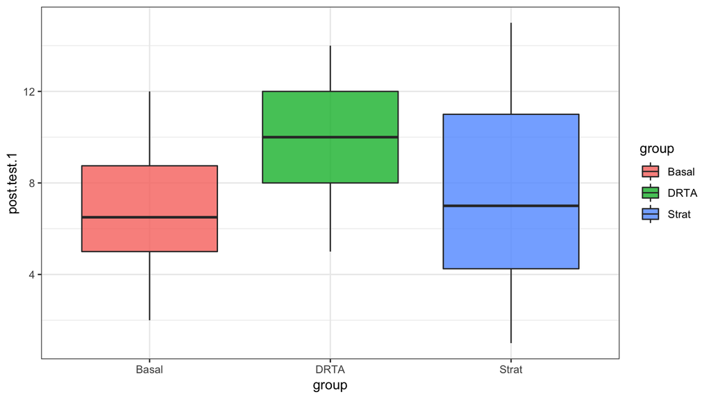

Será que o método de ensino influencia nas notas das provas? Como?

# Baumann e Jones

Antes de fazer múltiplas comparações, é melhor ver se há efeito principal de técnica de ensino no resultado de post.test.1.

Faça isso e reporte sua resposta como se você estivesse escrevendo um artigo.

# Baumann e Jones

Ei, volte para o slide anterior e tente fazer sem ver a resposta!!

# Baumann e Jones

Primeiro vemos se há um efeito principal de `group`.

```r
modelo.baumann <- aov(post.test.1 ~ group, data = Baumann)

summary(modelo.baumann)
```

Analysis of Variance Model

|  | Df | Sum Sq | Mean Sq | F value | Pr(>F) |
| --- | --- | --- | --- | --- | --- |
| **group** | 2 | 108.1 | 54.06 | 5.317 | 0.007347 |
| **Residuals** | 63 | 640.5 | 10.17 |  |  |

Há efeito principal de método de ensino?

- Sim!

# Baumann e Jones

Como há, faço um teste de Tukey para ver quais comparações foram significativas.

```r
TukeyHSD(modelo.baumann)
```

- **group**:

  |  | diff | lwr | upr | p adj |
  | --- | --- | --- | --- | --- |
  | **DRTA-Basal** | 3.091 | 0.7833 | 5.399 | 0.00576 |
  | **Strat-Basal** | 1.091 | -1.217 | 3.399 | 0.4965 |
  | **Strat-DRTA** | -2 | -4.308 | 0.3076 | 0.1021 |

# Baumann e Jones

- **group**:

  |  | diff | lwr | upr | p adj |
  | --- | --- | --- | --- | --- |
  | **DRTA-Basal** | 3.091 | 0.7833 | 5.399 | 0.00576 |
  | **Strat-Basal** | 1.091 | -1.217 | 3.399 | 0.4965 |
  | **Strat-DRTA** | -2 | -4.308 | 0.3076 | 0.1021 |

- Fizemos uma one-way ANOVA para testar o efeito da variável independente *método de ensino* nas notas da prova. O resultado indicou que o método de ensino influenciou as notas obtidas pelos alunos (F(2,63)=5.31, p = 0.007) . Análises post-hoc por meio de Teste de Tukey identificaram que a única diferença significativa se deu na comparação entre as notas dos alunos que tiveram aulas com método *Basal* e aqueles que tiveram aulas com o método *DRTA* (p = 0.005). Nesse caso, a média dos alunos do segundo grupo tiveram foram maiores.

# Two-way ANOVA com interação

# Exemplo

O efeito do produto de limpeza depende do tipo de dejeto? Qual a fórmula?

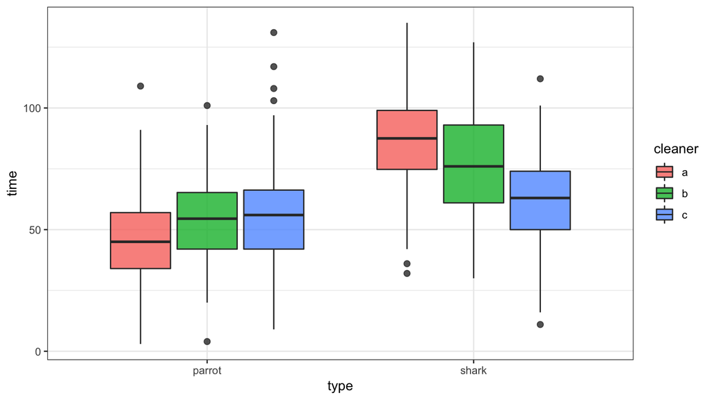

- Fórmula: `time ~ cleaner * type`

# Exemplo

Two-way ANOVA com interação: O efeito do produto de limpeza depende do tipo de dejeto? (time ~ cleaner * type)

Primeiro nós fazemos um modelo, com a função `aov` para responder a pergunta que nos interessa.

```r
modelo.cleaner.int.type <- aov(time ~ cleaner * type, data = poopdeck)
```

Agora tiramos a nossa tabela desse modelo através da função `summary`

```r
summary(modelo.cleaner.int.type)
```

# Exemplo

```r
modelo.cleaner.int.type <- aov(time ~ cleaner * type, data = poopdeck)

summary(modelo.cleaner.int.type)
```

Analysis of Variance Model

|  | Df | Sum Sq | Mean Sq | F value | Pr(>F) |
| --- | --- | --- | --- | --- | --- |
| **cleaner** | 2 | 6057 | 3028 | 7.82 | 0.000443 |
| **type** | 1 | 81620 | 81620 | 211 | 4.16e-41 |
| **cleaner:type** | 2 | 29968 | 14984 | 38.7 | 1.57e-16 |
| **Residuals** | 594 | 229923 | 387 |  |  |

Perceba que agora há duas linhas que mostram a variação *entre grupos* - *cleaner* e *type* - e uma linha que mostra a variação proveniente da interação entre esses termos: *cleaner:type*.

A linha que mostra a variação *dentro dos grupos* recebe o nome de *Residuals*.

# Exemplo

```r
modelo.cleaner.int.type <- aov(time ~ cleaner * type, data = poopdeck)

summary(modelo.cleaner.int.type)
```

Analysis of Variance Model

|  | Df | Sum Sq | Mean Sq | F value | Pr(>F) |
| --- | --- | --- | --- | --- | --- |
| **cleaner** | 2 | 6057 | 3028 | 7.82 | 0.000443 |
| **type** | 1 | 81620 | 81620 | 211 | 4.16e-41 |
| **cleaner:type** | 2 | 29968 | 14984 | 38.7 | 1.57e-16 |
| **Residuals** | 594 | 229923 | 387 |  |  |

Há *efeito principal* de tipo de dejeto e de tipo de produto ou *interação* entre os dois termos?

- Há um efeito do tipo de produto (F(2,594)=7.82, p = 0.001) e dejeto (F(1,594)=211, p < 0.0001) no tempo gasto para limpar o convés. A interação entre os fatores também foi significativa (F(2,594)=38.7, p < 0.0001).

# Exemplo

Mais uma vez, o teste de Tukey pode te dar as comparações em um teste post-hoc.

```r
TukeyHSD(modelo.cleaner.int.type)
```

`$cleaner`

|  | diff | lwr | upr | p adj |
| --- | --- | --- | --- | --- |
| b-a | -0.42 | -5.04266 | 4.20266 | 0.9751910 |
| c-a | -6.94 | -11.56266 | -2.31734 | 0.0013118 |
| c-b | -6.52 | -11.14266 | -1.89734 | 0.0028018 |

`$type`

|  | diff | lwr | upr | p adj |
| --- | --- | --- | --- | --- |
| shark-parrot | 23.32667 | 20.17176 | 26.48157 | 0 |

# Exemplo

`$cleaner:type`

|  | diff | lwr | upr | p adj |
| --- | --- | --- | --- | --- |
| b:parrot-a:parrot | 8.06 | 0.1051112 | 16.0148888 | 0.0449641 |
| c:parrot-a:parrot | 10.37 | 2.4151112 | 18.3248888 | 0.0028993 |
| a:shark-a:parrot | 40.52 | 32.5651112 | 48.4748888 | 0.0000000 |
| b:shark-a:parrot | 31.62 | 23.6651112 | 39.5748888 | 0.0000000 |
| c:shark-a:parrot | 16.27 | 8.3151112 | 24.2248888 | 0.0000001 |
| c:parrot-b:parrot | 2.31 | -5.6448888 | 10.2648888 | 0.9618601 |
| a:shark-b:parrot | 32.46 | 24.5051112 | 40.4148888 | 0.0000000 |
| b:shark-b:parrot | 23.56 | 15.6051112 | 31.5148888 | 0.0000000 |
| c:shark-b:parrot | 8.21 | 0.2551112 | 16.1648888 | 0.0385298 |
| a:shark-c:parrot | 30.15 | 22.1951112 | 38.1048888 | 0.0000000 |
| b:shark-c:parrot | 21.25 | 13.2951112 | 29.2048888 | 0.0000000 |
| c:shark-c:parrot | 5.90 | -2.0548888 | 13.8548888 | 0.2780324 |
| b:shark-a:shark | -8.90 | -16.8548888 | -0.9451112 | 0.0181288 |
| c:shark-a:shark | -24.25 | -32.2048888 | -16.2951112 | 0.0000000 |
| c:shark-b:shark | -15.35 | -23.3048888 | -7.3951112 | 0.0000008 |

# Exemplo

Os dejetos de tubarões levaram, em média, 23.3 minutos a mais para serem limpos do que dejetos de papagaio, e essa diferença foi significativa (p < 0.0001).

# Two-way Anova com interação: estudo de caso

# Covariaveis

Já conhecemos a tabela Covariaveis.csv (Oushiro, 2015). Usando-a, vamos responder a pergunta que segue:

Há efeito de gênero na taxa de produção de concordância nominal não-padrão e será que esse efeito depende do nível de escolaridade?

Quais são seus palpites?

# Covariaveis

Primeiros, vamos importar o conjunto de dados e fazer uma filtragem para eliminar os falantes estrangeiros

```r
covariaveis = read.csv("Covariaveis.csv")

covariaveis.br = covariaveis%>%
  filter(ORIGEM.PAIS != "estrangeiros")
```

# Covariaveis

Vamos dar uma olhada no boxplot para ter uma ideia da distribuição dos dados.

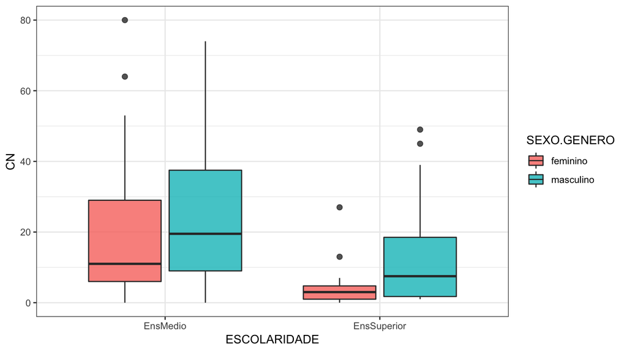

# Covariaveis

Para podermos fazer nossas análises, precisamos transformar* os dados, visto que não são normais (cf. Aula 7).

```r
covariaveis.br = covariaveis.br%>%
  mutate(CN.1 = CN+1)%>%
  mutate(CN.log = log(CN.1))
```

Agora faremos nossas análises a partir da nova coluna que tem os dados transformados.

* Alguns informantes tem valor igual a 0 na coluna CN, o que significa que ele não realizaou nenhuma CN não-padrão. Como é impossível fazer uma transformação logarítmica em 0, somamos 1 a todos os valores da coluna e, depois disso, realizamos a transformação.

# Covariaveis

Será que existe um efeito de gênero? Será que esse efeito depende da escolaridade?

Como é a sintaxe do modelo para investigar essas questões?

# Covariaveis

Vamos construir um modelo para uma análise Two-way ANOVA com interação e ver o resultado da Tabela ANOVA.

```r
modelo.CN <- aov(CN.log ~ SEXO.GENERO * ESCOLARIDADE, data = covariaveis.br)

summary(modelo.CN)
```

Analysis of Variance Model

|  | Df | Sum Sq | Mean Sq | F value | Pr(>F) |
| --- | --- | --- | --- | --- | --- |
| **SEXO.GENERO** | 1 | 11.13 | 11.13 | 10.36 | 0.001725 |
| **ESCOLARIDADE** | 1 | 24.54 | 24.54 | 22.85 | 5.85e-06 |
| **SEXO.GENERO:ESCOLARIDADE** | 1 | 0.8828 | 0.8828 | 0.8218 | 0.3668 |
| **Residuals** | 103 | 110.7 | 1.074 |  |  |

Há efeitos principais e de interação?

- Há apenas efeitos principais, mas não há interação.

# Covariaveis

Analysis of Variance Model

|  | Df | Sum Sq | Mean Sq | F value | Pr(>F) |
| --- | --- | --- | --- | --- | --- |
| **SEXO.GENERO** | 1 | 11.13 | 11.13 | 10.36 | 0.001725 |
| **ESCOLARIDADE** | 1 | 24.54 | 24.54 | 22.85 | 5.85e-06 |
| **SEXO.GENERO:ESCOLARIDADE** | 1 | 0.8828 | 0.8828 | 0.8218 | 0.3668 |
| **Residuals** | 103 | 110.7 | 1.074 |  |  |

Uma two-way ANOVA com interação testou os efeitos de gênero e escolaridade na produção da concordância nominal não-padrão. Houve efeito principal de gênero (F(1, 103)=10.36, p = 0.001) e escolaridade (F(1, 103)=22.85, p < 0.0001), mas a interação entre os fatores não se mostrou significativa (F(1, 103) = 0.82, p = 0.3)

# Covariaveis

Como não houve efeito de interação, o Teste Tukey deve fazer as análises apenas para os termos que foram significantes para o modelo: `SEXO.GENERO` e `ESCOLARIDADE`.

Especificamos isso na sintaxe no teste.

```r
TukeyHSD(modelo.CN, "SEXO.GENERO")

TukeyHSD(modelo.CN, "ESCOLARIDADE")
```

# Covariaveis

```r
TukeyHSD(modelo.CN, "SEXO.GENERO")

TukeyHSD(modelo.CN, "ESCOLARIDADE")
```

`$SEXO.GENERO`

|  | diff | lwr | upr | p adj |
| --- | --- | --- | --- | --- |
| masculino-feminino | 0.6456263 | 0.2477443 | 1.043508 | 0.0017254 |

`$ESCOLARIDADE`

|  | diff | lwr | upr | p adj |
| --- | --- | --- | --- | --- |
| EnsSuperior-EnsMedio | -0.9578818 | -1.355347 | -0.5604171 | 5.9e-06 |

# Covariaveis

Se pensarmos bem, não precisaríamos fazer um teste post-hoc, visto que nosso experimento é 2x2, e a diferença indicada em gênero diz respeito à diferença feminino x masculino e a diferença de escolaridade já dá a diferença entre ensino médio x ensino superior.

Os testes post-hoc vão ser úteis para as situações em que temos interação, ou um experimento com variável de 3 níveis (como a variável `cleaner`, no conjunto `poopdeck`)

Vamos comparar:

# Covariaveis

Analysis of Variance Model

|  | Df | Sum Sq | Mean Sq | F value | Pr(>F) |
| --- | --- | --- | --- | --- | --- |
| **SEXO.GENERO** | 1 | 11.13 | 11.13 | 10.36 | 0.001725 |
| **ESCOLARIDADE** | 1 | 24.54 | 24.54 | 22.85 | 5.85e-06 |
| **SEXO.GENERO:ESCOLARIDADE** | 1 | 0.8828 | 0.8828 | 0.8218 | 0.3668 |
| **Residuals** | 103 | 110.7 | 1.074 |  |  |

$SEXO.GENERO

|  | diff | lwr | upr | p adj |
| --- | --- | --- | --- | --- |
| masculino-feminino | 0.6456263 | 0.2477443 | 1.043508 | 0.0017254 |

$ESCOLARIDADE

|  | diff | lwr | upr | p adj |
| --- | --- | --- | --- | --- |
| EnsSuperior-EnsMedio | -0.9578818 | -1.355347 | -0.5604171 | 5.9e-06 |

# Covariaveis

Uma two-way ANOVA com interação testou os efeitos de gênero e escolaridade na produção da concordância nominal não-padrão. Houve efeito principal de gênero (F(1, 103)=10.36, p = 0.001) e escolaridade (F(1, 103)=22.85, p < 0.0001), mas a interação entre os fatores não se mostrou significativa (F(1, 103) = 0.82, p = 0.3).

De modo geral, mulheres produziram a variante não-padrão em menor taxa que homens, e falantes com ensino superior produziram produziram tal variante com menos frequência que falantes com ensino médio.

# ANOVA: uma revisão

# Pré-requisitos

Antes de realizar uma ANOVA, certifique-se de que

- suas variáveis independentes são categóricas
- sua variável dependente é numérica e contínua
- a distribuição dos dados da sua variável dependente é normal
- o n entre os grupos é balanceado

# Após a ANOVA

- Lembre-se de reportar claramente quais foram as variáveis do seu modelo
- Realize um teste Tukey, quando necessário, apenas para os termos que mostraram significância estatística na ANOVA

# Revisão

# Comandos para realizar uma anova

Como vimos, primeiro criamos um modelo com a função `aov`, e depois realizamos o teste de Tukey.

```r
modelo.aov <- aov(x ~ y, data)

TukeyHSD(modelo.aov, "y")
```